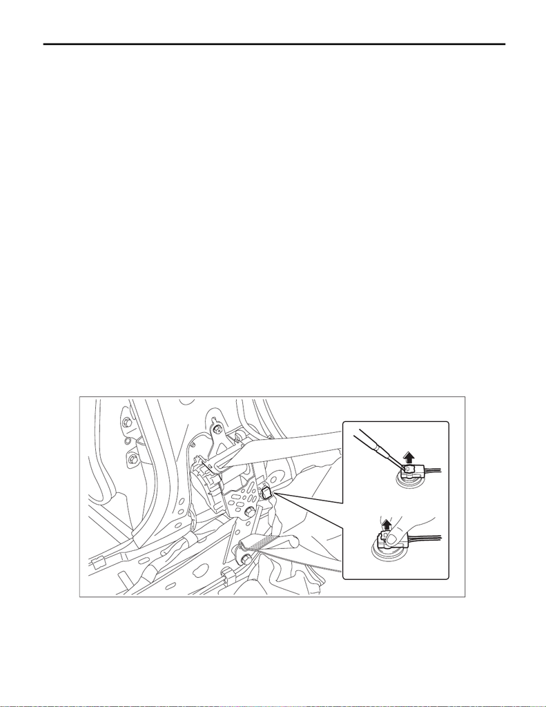

SB-29

Disposal of Pretensioner

SEAT BELT SYSTEM

7. Disposal of Pretensioner

A: PROCEDURE

WARNING:

Make sure to follow the instructions below. Otherwise, personal injuries may occur.

• Before discarding a pretensioner, always perform an activation process to prevent any false acti-

vation.

• Wear protective gloves, safety goggles and earplugs during this operation. Wash your hands af-

terwards.

• Do not touch the pretensioner just after activation because it is very hot. Before handling it for dis-

posal, wait for 40 minutes.

CAUTION:

• Perform a pretensioner operation process in a safe, level place. Do not perform the process out-

doors when there is a strong rain or wind.

• Do not drop or damage the pretensioner.

• A large explosive noise will occur when the pretensioner is deployed. Warn persons in the area,

and do not allow anyone to approach a radius of 5 m (16 ft) from the discard location.

• After activating the pretensioner, smoke may arise. Therefore, always perform an operation pro-

cess in a well-ventilated place without any smoke sensor.

• Do not expose the activated pretensioner to water.

• Wrap the activated pretensioner in a sealed vinyl bag when discarding.

• If it is impossible to perform a pretensioner activation process due to some situational reasons,

consult SUBARU dealership or one of the authorized workshops.

1) Fold the backrest all the way forward, and move the front seat all the way forward.

2) Turn the ignition switch to OFF.

3) Disconnect the ground cable from battery and wait for at least 60 seconds before starting work. <Ref. to

NT-5, BATTERY, NOTE, Note.>

NOTE:

For models other than STI model, disconnect the ground terminal from battery sensor.

4) Disconnect connector (a) of the pretensioner.

5) Short the alligator clip and terminal of the airbag deployment tool together.

CAUTION:

Short the airbag deployment tool terminals until just before the pretensioner operation process.

Preparation tool:

ST: AIRBAG DEPLOYMENT TOOL (98299PA030)

SB-00495

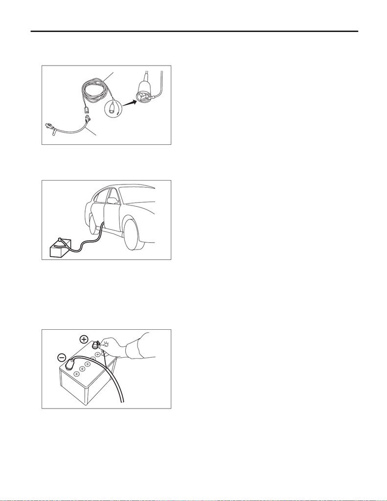

SB-30

Disposal of Pretensioner

SEAT BELT SYSTEM

6) Connect the airbag deployment tool (A) and test harness adapter D (B).

Preparation tool:

ST: TEST HARNESS ADAPTER D (98299SA010)

7) Connect the test harness adapter D connector to the pretensioner.

8) Make sure there is no one inside the vehicle.

9) Extend the wiring of the airbag deployment tool to its limit, and completely close all the windows and sun-

roof.

10) Move the battery 5 m (16 ft) or more from the vehicle, and affix nearby.

11) Connect the airbag deployment tool alligator clip to the battery negative (–) terminal.

12) Connect the other cable of airbag deployment tool to the battery positive (+) terminal, and activate the

pretensioner.

CAUTION:

• After activation, the pretensioner will be extremely hot. Let it cool down for at least 40 minutes in

an area with no one around.

• Do not expose the activated pretensioner to water.

15) Short the alligator clip and terminal of the airbag deployment tool together.

CAUTION:

Short the airbag deployment tool terminals until just before the pretensioner operation process.

Preparation tool:

ST: AIRBAG DEPLOYMENT TOOL (98299PA030)

SB-00021

(A)

(B)

SB-00496

SB-00018

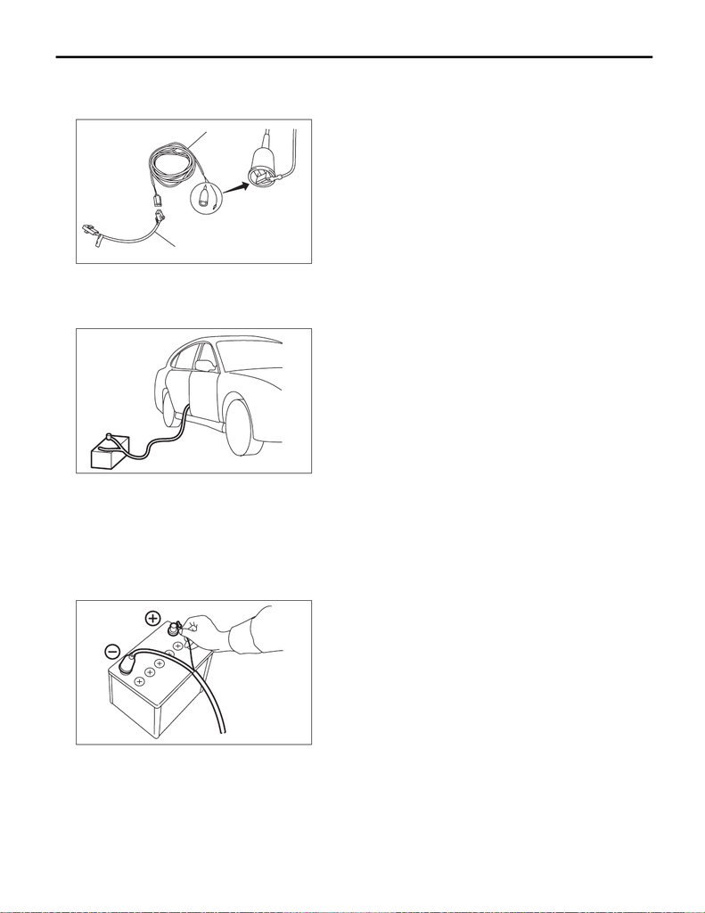

SB-31

Disposal of Pretensioner

SEAT BELT SYSTEM

16) Connect the airbag deployment tool (A) and test harness adapter D (B).

Preparation tool:

ST: TEST HARNESS ADAPTER D (98299SA010)

17) Connect the test harness adapter D connector to the lap seat belt pretensioner.

18) Make sure there is no one inside the vehicle.

19) Extend the wiring of airbag deployment tool to the limit, and close all the windows and sunroof complete-

ly.

20) Move the battery 5 m (16 ft) or more from the vehicle, and affix nearby.

21) Connect the airbag deployment tool alligator clip to the battery negative (–) terminal.

22) Connect the other cable of airbag deployment tool to the battery positive (+) terminal, and activate the

pretensioner.

CAUTION:

• After activation, the pretensioner will be extremely hot. Let it cool down for at least 40 minutes in

an area with no one around.

• Do not expose the activated pretensioner to water.

23) Remove the seat belt outer - front. <Ref. to SB-16, REMOVAL, Front Seat Belt.>

SB-00021

(A)

(B)

SB-00496

SB-00018

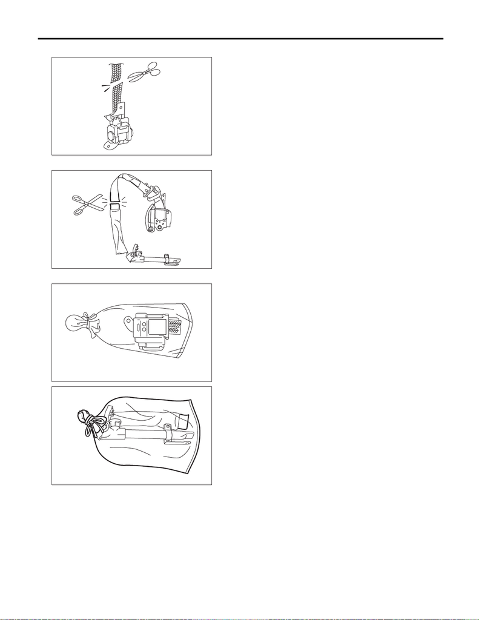

SB-32

Disposal of Pretensioner

SEAT BELT SYSTEM

24) Cut the seat belt at a position as close as possible to the seat belt retractor.

25) Cut the seat belt at a position as close as possible to the lap seat belt pretensioner.

26) Place the activated pretensioner in a sealed vinyl bag, then discard.

SB-00130

SB-00027

SB-00131

SB-00022

[figure not shown]

LIGHTING SYSTEM

LI

Page

1. General Description ...................................................................................2

2. Relay and Fuse ..........................................................................................4

3. Headlight System .......................................................................................6

4. Day Time Running Light System ................................................................9

5. Clearance Light and Illumination Light System ........................................10

6. Front Fog Light System ............................................................................11

7. Turn Signal Light and Hazard Light System .............................................12

8. Back-up Light System ..............................................................................13

9. Stop Light System ....................................................................................14

10. Interior Light System ................................................................................15

11. Auto Headlight Beam Leveler System .....................................................16

12. Combination Switch (Light) ......................................................................18

13. Light Control Sensor ................................................................................21

14. Headlight Assembly .................................................................................23

15. Headlight Bulb ..........................................................................................29

16. Hazard Switch ..........................................................................................31

17. Turn Signal Light & Hazard Light Module ................................................33

18. Front Turn Signal Light Assembly ............................................................35

19. Front Turn Signal Light Bulb ....................................................................38

20. Clearance/Parking Light Bulb ...................................................................39

21. Front Side Marker Light Bulb ...................................................................40

22. Front Fog Light Assembly ........................................................................41

23. Front Fog Light Bulb .................................................................................46

24. Side Turn Signal Light Assembly .............................................................48

25. Rear Combination Light Assembly ...........................................................49

26. Tail/Stop Light Bulb ..................................................................................52

27. Rear Turn Signal Light Bulb .....................................................................53

28. Rear Side Marker Light Bulb ....................................................................54

29. Back-up Light Bulb ...................................................................................55

30. License Plate Light ...................................................................................56

31. High-mounted Stop Light .........................................................................58

32. Spot Map Light .........................................................................................60

33. Room Light ...............................................................................................62

34. Trunk Room Light .....................................................................................64

35. LED Illumination Light ..............................................................................66

36. Vanity Mirror Light ....................................................................................68

37. Ignition Switch Illumination .......................................................................69

38. Auto Headlight Beam Leveler Control Module .........................................71

39. Rear Height Sensor ..................................................................................74

40. Day Time Running Resistor .....................................................................76

41. Door Switch ..............................................................................................78